# Lab Quiz 2

October 4, 2019

General Instructions for all quizzes:

1. Put all cell-phones away completely, and do NOT take them out until you leave the lab.
2. Do not turn on any email program.
3. Do not talk to anyone except to Seth and me.
4. Do not look at others’ computer screen.
5. You may use all past lab material
6. When the quiz says “Write code …” send your code ONLY (NOT the output, figs, .).
7. Parse your answers with the corresponding quiz parts, i.e., # a) , # b), etc.
8. Solutions submitted after 5:30 will not be accepted.

(The actual questions are in *italic*)

In this lab we will numerically demonstrate some of the claims made in the lecture. The main tool will be simulation of the type you did last week.

*a) write code to draw 10000 samples of size n=10 from a standard normal distribution, make a density-scale histogram of the 10000 values of X (with around 200 breaks), and superimpose on it the theoretical chi-squared pdf with df = n-1.*

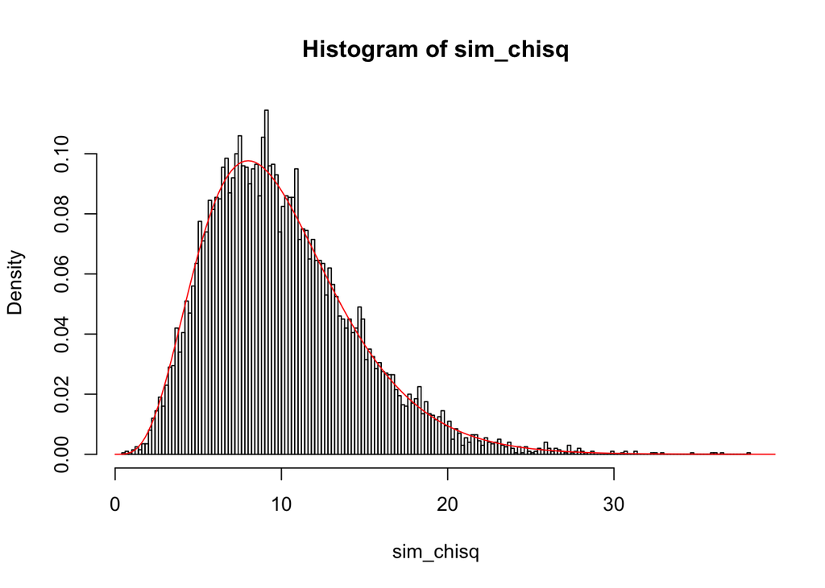

```r
# write your code here
trial <- 10000
sim_chisq <- numeric(trial)
samp_size <- 10

for (i in 1:trial) {
  samp <- rnorm(samp_size, 0, 1)
  sim_chisq[i] <- sum(samp^2)
}
hist(sim_chisq, freq=F, breaks=200)

x_val <- seq(0, 50, by=0.2)
y_val <- dchisq(x_val, df=samp_size)
lines(x_val, y_val, col=2)
```

*b) Hopefully, the agreement between the hist and the dist will be close, but it won’t be as close as we may have expected based on theory. What’s the reason for the difference? Feel free to experiment with your code.*

may be because of simulation size, or the break number.

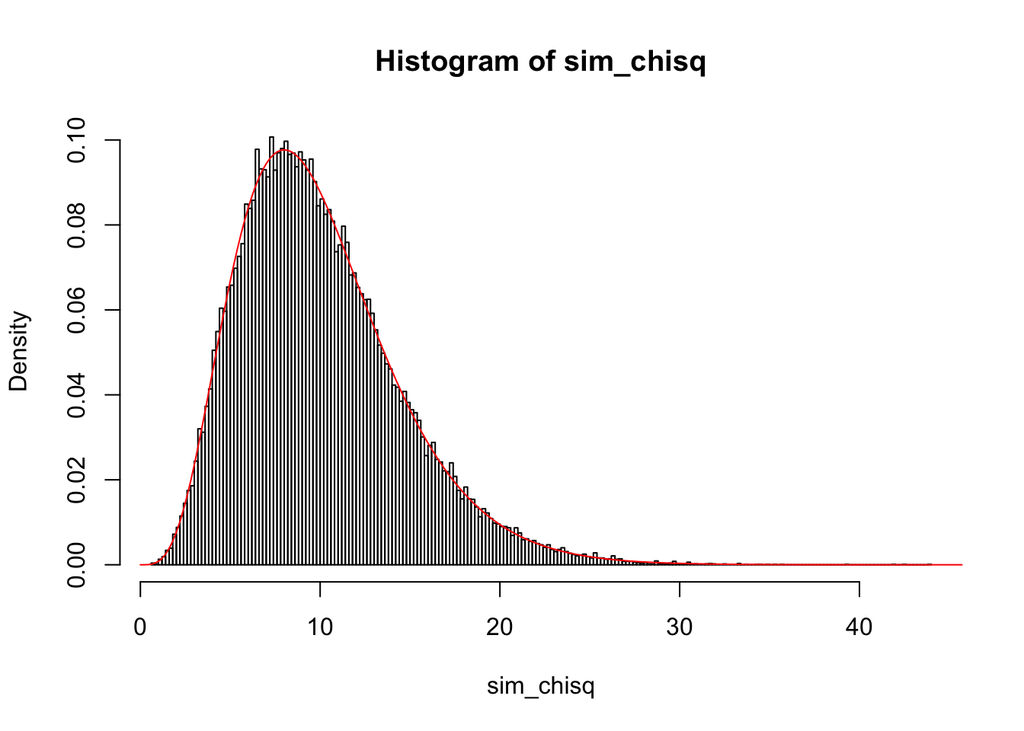

```r
# optional space to experiment with code

## simulation of 50000
trial <- 50000
sim_chisq <- numeric(trial)
samp_size <- 10

for (i in 1:trial) {
  samp <- rnorm(samp_size, 0, 1)
  sim_chisq[i] <- sum(samp^2)
}
hist(sim_chisq, freq=F, breaks=200)

x_val <- seq(0, 50, by=0.2)
y_val <- dchisq(x_val, df=samp_size)
lines(x_val, y_val, col=2)
```

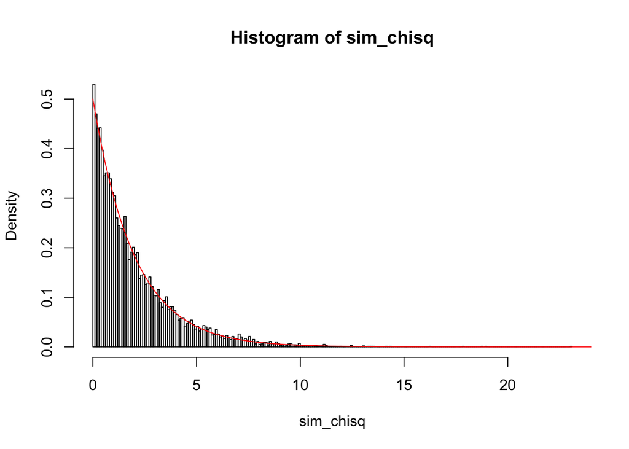

```r
## sample size of 2
trial <- 10000
sim_chisq <- numeric(trial)
samp_size <- 2

for (i in 1:trial) {
  samp <- rnorm(samp_size, 0, 1)
  sim_chisq[i] <- sum(samp^2)
}
hist(sim_chisq, freq=F, breaks = 200)

x_val <- seq(0, 50, by=0.2)
y_val <- dchisq(x_val, df=samp_size)
lines(x_val, y_val, col=2)
```

I have claimed that $(n-1)s^2/\sigma^2$ has a chi-squared dist with $df=n-1$. Confirm that claim through simulation. Specifically,

*c) Write code to draw 10000 samples of size n=100 from a N(3,2), compute* $(n-1)s^2/\sigma^2$ for *each sample, make a density-scale histogram (with about 200 breaks) of the 10000 values of* $(n-1)s^2/\sigma^2$

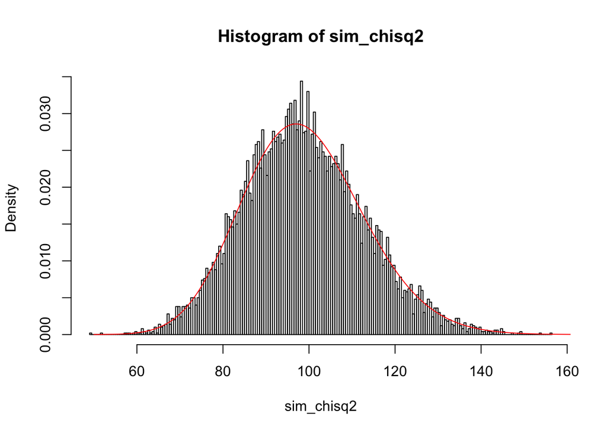

```r
# write your code here
trial <- 10000
n <- 100
mu <- 3
sigma <- 2
sim_chisq2 <- numeric(trial)

for (i in 1:trial) {
  samp <- rnorm(n, mu, sigma)
  sim_chisq2[i] <- (n - 1)*var(samp) / sigma^2
}

hist(sim_chisq2, freq=F, breaks=200)

x_val <- seq(50, 200, 0.5)
y_val <- dchisq(x_val, n-1)
lines(x_val, y_val, col=2)
```

I have claimed that $s_1^2/s_2^2$ has an F-distribution with df = (d1,d2) with d1=n1-1 and d2=n2-1, if the two populations have equal variances. Confirm that claim through simulation. Specifically,

*d) Write code to draw 10000 samples of size n=100 from a normal distribution with mu1 = 3, sigma1 = 2, and an independent sample of size n=50 from a normal distribution with mu2 = 3.1, sigma2 = 2.1, and make a density-scale histogram (with about 200 breaks) of the 10000 values of* $s_1^2/s_2^2$.

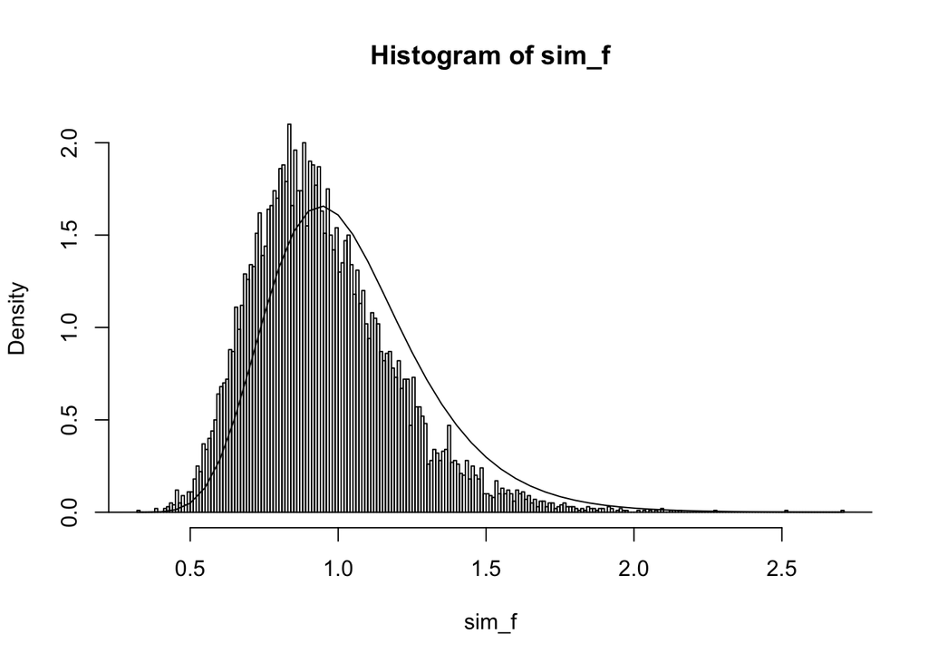

```r
# write your code here
mu1 <- 3
mu2 <- 3.1
sigma1 <- 2
sigma2 <- 2.1
trial <- 10000
n1 <- 100
n2 <- 50
sim_f <- numeric(trial)

for (i in 1:trial) {
  samp1 <- rnorm(n1, mu1, sigma1)
  samp2 <- rnorm(n2, mu2, sigma2)
  sim_f[i] <- var(samp1) / var(samp2)
}
hist(sim_f, freq=F, breaks = 200)
x_val <- seq(0, 5, by=0.05)
y_val <- df(x_val, n1-1, n2-1)
lines(x_val, y_val)
```

*e) Why is the agreement between the hist and the dist in part d) only approximate?*

Because f distribution requires two population have same variance, however, in this case, we draw samples from sigma 2 and sigma 2.1, which leads to the difference between sampling distribution and theoretical plots.

Finally, we talked about how if we think of y_i, i=1,2,…,n, as having n degrees of freedom, then (y_i - y_bar), i = 1, 2, …, n, have (n-1) degrees of freedom because of the 1 constraint sum_i^n (y_i - y_bar) = 0. There is a geometric way of seeing this result. Let’s set n=3 just so that we can make plots. Suppose we want to see the 3d space in which 100 possible triples (y_1, y_2, y_3) live. To that end, run the following code

```r
n = 100
y = matrix(nrow=n, ncol=3)
for(i in 1:3){
   y[,i] = runif(n,-1,1)
}
```

So, you now have 100 triples of observations. Think of each triple as a sample of size 3. If we want to see the 3d space in which each of these samples of size 3 lives we can make a 3d scatterplot of the 100 points, as follows. You’ll see that the points live in a 3d space.

```r
#install.packages("rgl")
library(rgl)   # You may use any 3d plotter in R that you prefer.
plot3d(y)
```

*f) Now, write code to compute the sample mean for each sample (of size 3), subtract that mean from each of the elements in the sample, and make the 3d scatterplot of the resulting 100 point. Note that in this part, the word “sample” refers to each of the triples; i.e., we are dealing with 100 samples of size 3.*

```r
# write your code here
new_y <- matrix(nrow=n, ncol=3)
for (i in 1:n) {
  samp_mean <- mean(y[i,])
  new_y[i,] <- y[i,] - samp_mean
}

plot3d(new_y)
```